# Data Visualization Project 3 Data Storytelling: Open Project

Amukta Gantalamohini Northeastern University INSH 5302: Information Design and Visual Analytics

April 21, 2026

# Introduction

> What factors influence the price and auction popularity of Mario Kart Wii auctions on eBay?

This project analyzes data from Mario Kart Wii auctions on eBay from October of 2009. Visualizations were created between variables to understand their relationship and how they impact the price and the overall auction of the game. Scatterplots were used to understand the number of bids and a seller’s rating, and boxplots and bar charts were used to compare pricing, bidding. These variables were compared against others such as the number of wheel controls included and the auction’s duration. A density plot revealed the overall distribution of total prices paid among new and used. These visualization comprehensively looked at the Mario Kart Wii auction market on Ebay, highlighting differences in the condition of the games, the sellers, buyers, and the overall auction.

## Data

### Load Libraries and Packages

```r
# Type your code here...
library("moderndive")
library(dplyr)
library(mosaic)
library(ggplot2)
library(wordcloud)
library(tm)
```

### Description of data

This project analyzes data from Mario Kart Wii auctions on eBay, sourced from the mario_kart_auction dataset in R (from the ‘monderndive’ library). The data set originally contained 143 auctions across 12 variables, and after removing missing values and selecting relevant variables, the cleaned data set retained information on game condition, starting price, total price, auction price, shipping method, shipping price, seller rating, number of bids, auction duration, and number of Wii wheels included. I chose this data set as I wanted to do the final project on something lighthearted and fun.

> Topic or Package: Moderndive Data set: [ mario_kart_auction]

### Load and Clean Data

```r
# Type your code here...
data(mario_kart_auction)
na_data<- na.omit(mario_kart_auction)

data_cleaned <- na_data %>% select (-c(stock_photo, id ))

data_cleaned <- data_cleaned %>% mutate(auction_pr = total_pr - ship_pr)
```

### Preview Data

```r
# Type your code here...
head(data_cleaned)
```

| duration | n_bids | cond | start_pr | ship_pr | total_pr | ship_sp | seller_rate | wheels | title | auction_pr |
| --- | --- | --- | --- | --- | --- | --- | --- | --- | --- | --- |
| 3 | 20 | new | 0.99 | 4.00 | 51.55 | standard | 1580 | 1 | ~~ Wii MARIO KART & WHEEL ~ NINTENDO Wii ~ BRAND NEW ~~ | 47.55 |
| 7 | 13 | used | 0.99 | 3.99 | 37.04 | firstClass | 365 | 1 | Mariokart Wii Nintendo with wheel - Mario Kart Nintendo | 33.05 |
| 3 | 16 | new | 0.99 | 3.50 | 45.50 | firstClass | 998 | 1 | Mario Kart Wii (Wii) | 42.00 |
| 3 | 18 | new | 0.99 | 0.00 | 44.00 | standard | 7 | 1 | Brand New Mario Kart Wii Comes with Wheel. Free Ship | 44.00 |
| 1 | 20 | new | 0.01 | 0.00 | 71.00 | media | 820 | 2 | BRAND NEW NINTENDO 1 WII MARIO KART WITH 2 WHEELS +GAME | 71.00 |
| 3 | 19 | new | 0.99 | 4.00 | 45.00 | standard | 270144 | 0 | Mario Kart Wii (GAME ONLY/NO WHEEL) - Nintendo Wii Game | 41.00 |

### Variables

```r
# Type your code here...
names(data_cleaned)
```

```
##  [1] "duration"    "n_bids"      "cond"        "start_pr"    "ship_pr"
##  [6] "total_pr"    "ship_sp"     "seller_rate" "wheels"      "title"
## [11] "auction_pr"
```

The variables featured in this data visualization project are:

1. id: The Auction ID assigned by Ebay
2. duration: The auction length (days)
3. n_bids:Number of bids
4. cond: Game condition (new or used)
5. start_pr: Start price of the auction 6.ship_pr: Shipping price
6. total_pr: Total price, auction price plus shipping price 8 ship_sp: Shipping speed or method
7. seller_rate: The seller’s rating on Ebay, number of positive ratings minus the number of negative ratings
8. wheels: Number of Wii wheels included in the auction
9. title: The title of the auction

# Data Analysis

## Required Analysis

### Summary Statistics

```r
duration_stats <- favstats(data_cleaned$duration)
bids_stats<- favstats(data_cleaned$n_bids)
start_price_stats <- favstats(data_cleaned$start_pr)
total_price_stats<- favstats(data_cleaned$total_pr)
sellar_rate_stats<- favstats(data_cleaned$seller_rate)
wheels_stats<- favstats(data_cleaned$wheels)
cond_price_stats <- favstats(start_pr~cond, data= data_cleaned)
wheels_bids <- favstats(n_bids~wheels, data=data_cleaned)
```

### Chart/Graph

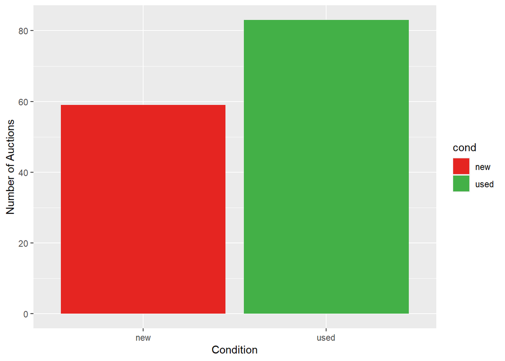

```r
#plots for condition of games

#condition and number of auctions
ggplot(cond_price_stats, aes(x = cond, y = n, fill = cond)) +
  geom_bar(stat = "identity") +
  scale_fill_manual(values = c("new" = "#E52521", "used" = "#43B047")) +
  labs(x = "Condition", y = "Number of Auctions")
```

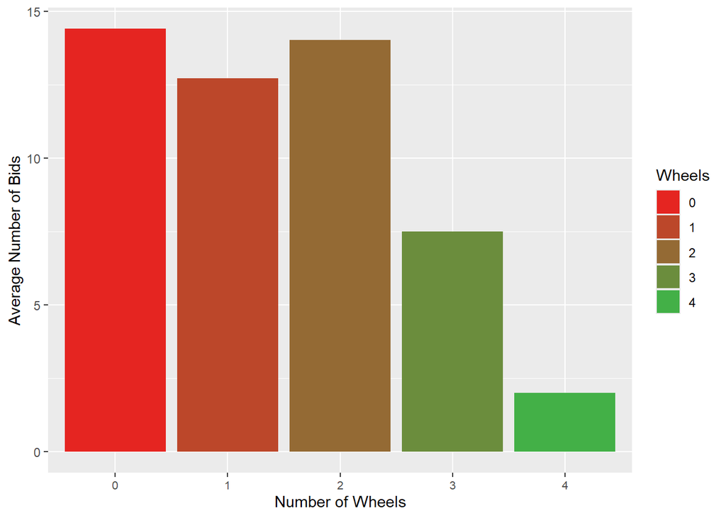

```r
ggplot(wheels_bids, aes(x = factor(wheels), y = mean, fill = factor(wheels))) +
  geom_bar(stat = "identity") +
  scale_fill_manual(values = colorRampPalette(c("#E52521", "#43B047"))(5)) +
  labs(x = "Number of Wheels", y = "Average Number of Bids", fill = "Wheels") +
  theme(axis.text.x = element_text(size = 8))
```

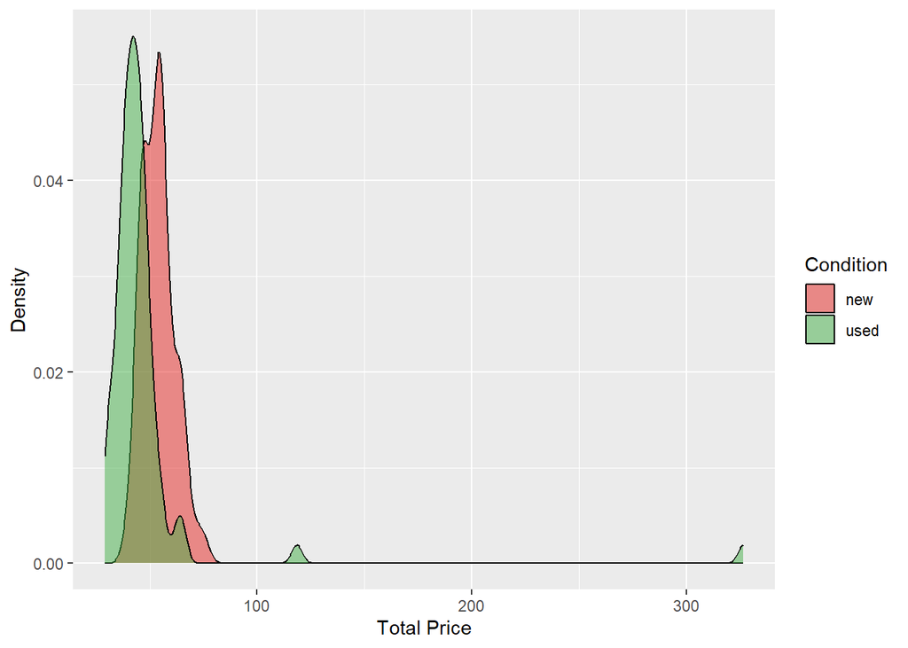

```r
ggplot(data_cleaned, aes(x = total_pr, fill = cond)) +
  geom_density(alpha = 0.5) +
  scale_fill_manual(values = c("new" = "#E52521", "used" = "#43B047")) +
  labs(x = "Total Price", y = "Density", fill = "Condition")
```

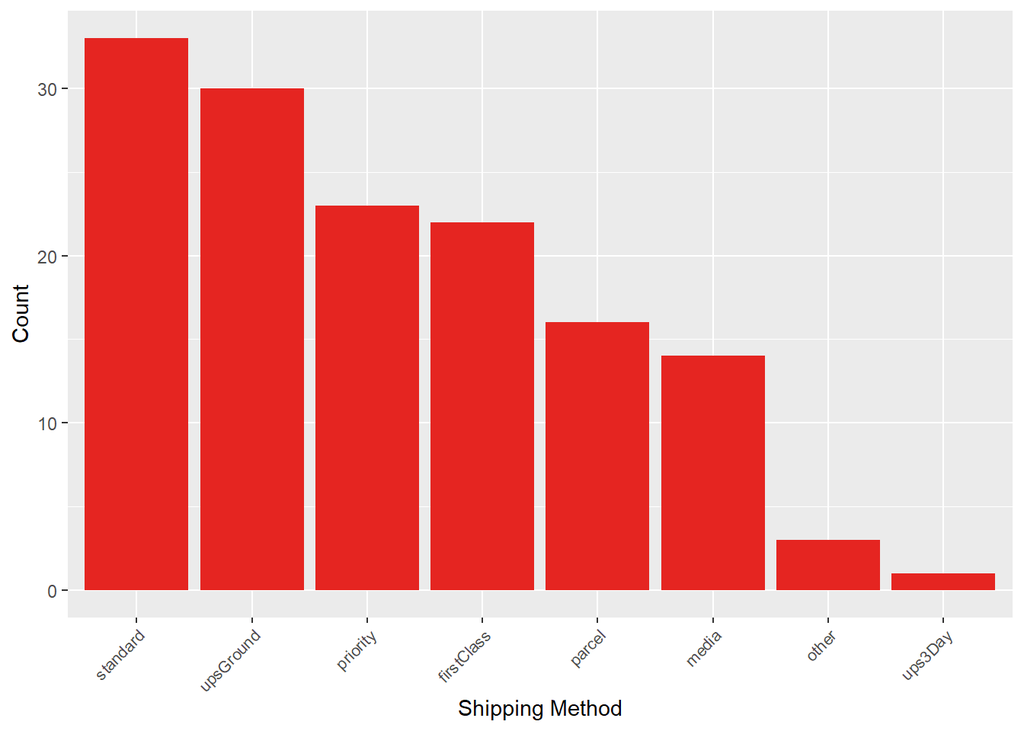

```r
ggplot(data_cleaned, aes(x = reorder(ship_sp, ship_sp, function(x) -length(x)))) +
  geom_bar(fill = "#E52521") +
  labs(x = "Shipping Method", y = "Count") + theme(axis.text.x = element_text(angle = 45, hjust = 1, size = 8))
```

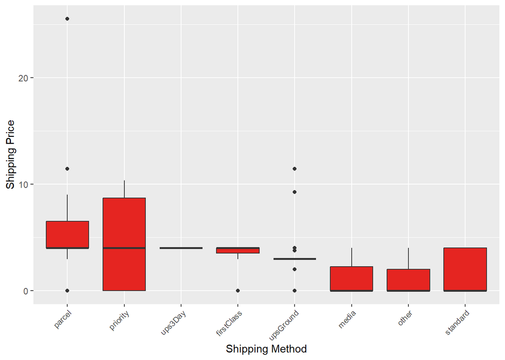

```r
ggplot(data_cleaned, aes(x = reorder(ship_sp, -ship_pr, median), y = ship_pr)) +
  geom_boxplot(fill = "#E52521") +
  labs(x = "Shipping Method", y = "Shipping Price") +
  theme(axis.text.x = element_text(angle = 45, hjust = 1, size = 8))
```

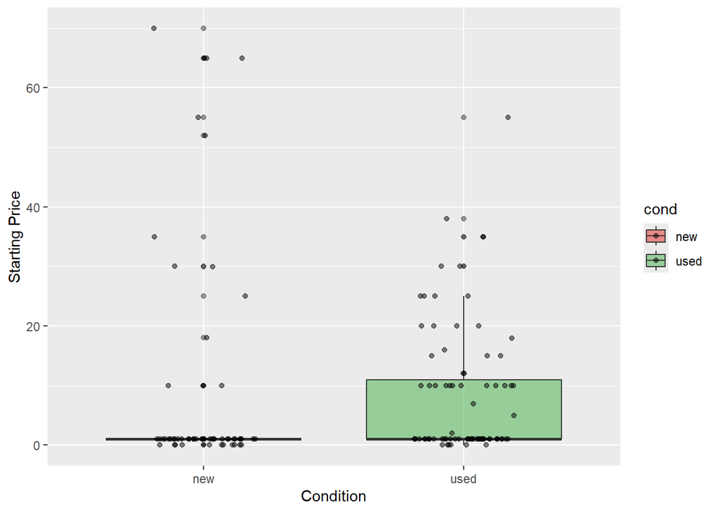

```r
ggplot(data_cleaned, aes(x = cond, y = start_pr, fill = cond)) +
  geom_boxplot(alpha = 0.5) +
  geom_jitter(width = 0.2, alpha = 0.5) +
  scale_fill_manual(values = c("new" = "#E52521", "used" = "#43B047")) +
  labs(x = "Condition", y = "Starting Price")
```

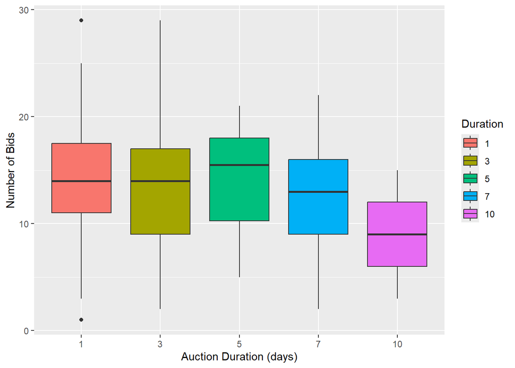

```r
ggplot(data_cleaned, aes(x = factor(duration), y = n_bids, fill = factor(duration))) +
  geom_boxplot() +
  labs(x = "Auction Duration (days)", y = "Number of Bids", fill = "Duration")
```

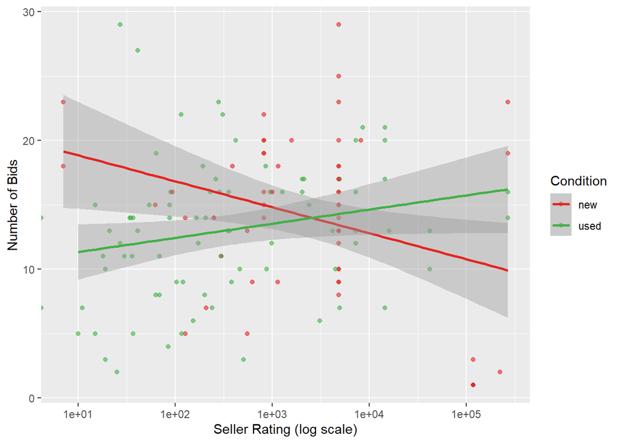

```r
ggplot(data_cleaned, aes(x = seller_rate, y = n_bids, color = cond)) +
  geom_point(alpha = 0.6) +
  geom_smooth(method = "lm") +
  scale_x_log10() +
  scale_color_manual(values = c("new" = "#E52521", "used" = "#43B047")) +
  labs(x = "Seller Rating (log scale)", y = "Number of Bids", color = "Condition")
```

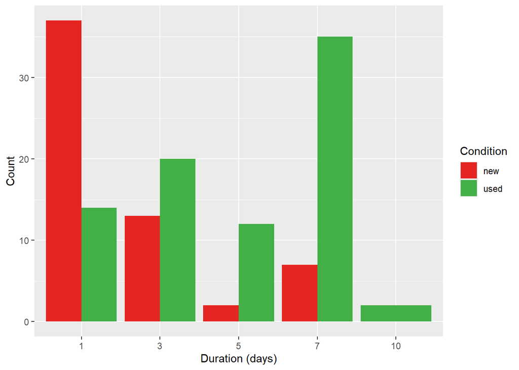

```r
# How many auctions by duration?
ggplot(data_cleaned, aes(x = factor(duration), fill = cond)) +
  geom_bar(position = "dodge") +
  scale_fill_manual(values = c("new" = "#E52521", "used" = "#43B047")) +
  labs(x = "Duration (days)", y = "Count", fill = "Condition")
```

## Additional Analyses

```r
title_corpus <- Corpus(VectorSource(data_cleaned$title))
title_corpus <- tm_map(title_corpus, removeWords, stopwords("english"))
title_corpus <- tm_map(title_corpus, removePunctuation)
title_corpus <- tm_map(title_corpus, content_transformer(tolower))
```

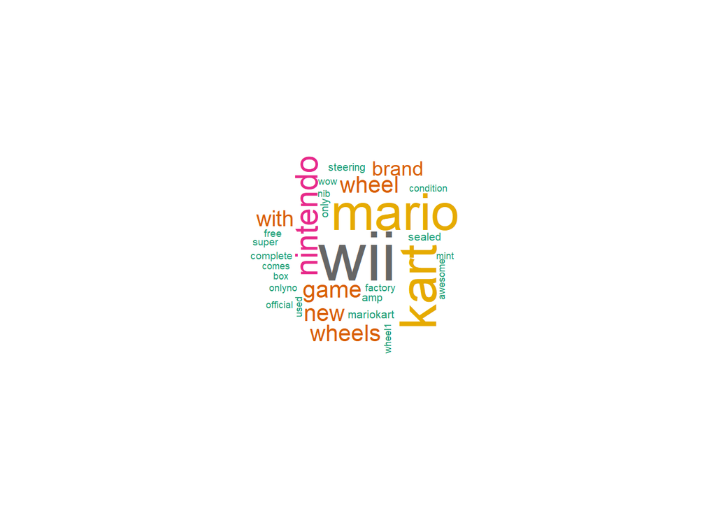

```r
wordcloud(title_corpus,
          max.words = 50,
          random.order = FALSE,
          colors = brewer.pal(8, "Dark2"))
```

```r
#calculating the table for the canva tree map
three_level_price <- data_cleaned %>%
  group_by(cond, wheels) %>%
  summarise(avg_price = round(mean(auction_pr), 2),
            n = n()) %>%
  arrange(cond, wheels)
```

# Option 4: Interactive Canva Website/Presentation Information Hub

[interactive chart not shown]

[Mario Kart Wii Auctions on Ebay](https://www.canva.com/design/DAHHUgYqU74/5iw3sJXmRkZj4kDjG7rqzg/view?utm_content=DAHHUgYqU74&utm_campaign=designshare&utm_medium=embeds&utm_source=link) by Amukta Gantalamohini

URL Link to Canva Site: Amukta Gantalamohini - Data Viz Project 3

# References

1.Title Photo: http://www.nintendoworldreport.com/feature/28551/the-innovations-of-mario-kart-mario-kart-wii